# FML - Assignment_2

Roopali Aggarwal

2024-02-23

Problem Statement - Universal bank is a young bank growing rapidly in terms of overall customer acquisition. The majority of these customers are liability customers (depositors) with varying sizes of relationship with the bank. The customer base of asset customers (borrowers) is quite small, and the bank is interested in expanding this base rapidly in more loan business. In particular, it wants to explore ways of convering its liability customers to personal loan customers.

A campaign that the bank ran last year for liability customers showed a healthy conversion rate of over 9% success. This has encouraged the retail marketing department to devise smarter campaigns with beƩer target marketing. The goal is to use k-NN to predict whether a new customer will accept a loan offer. This will serve as the basis for the design of a new campaign.

The file UniversalBank.csv contains data on 5000 customers. The data include customer demographic information (age, income, etc.), the customer’s relationship with the bank (mortgage, securities account, etc.), and the customer response to the last personal loan campaign (Personal Loan). Among these 5000 customers, only 480 (= 9.6%) accepted the personal loan that was offered to them in the earlier campaign.

Partition the data into training (60%) and validation (40%) sets.

```r
#loading the required libraries
library(dplyr)
library(class)
library(caret)
```

```r
library(ggplot2)
library(lattice)
library(e1071)
#Read the data using the working directory
getwd()
```

```
## [1] "/Users/roopaliaggarwal/Desktop"
```

```r
universal.bank <- read.csv("/Applications/UniversalBank.csv")
#Summary of the data and showing dimensions
summary(universal.bank)
```

```
##        ID            Age          Experience       Income          ZIP.Code
##  Min.   :   1   Min.   :23.00   Min.   :-3.0   Min.   :  8.00   Min.   : 9307
##  1st Qu.:1251   1st Qu.:35.00   1st Qu.:10.0   1st Qu.: 39.00   1st Qu.:91911
##  Median :2500   Median :45.00   Median :20.0   Median : 64.00   Median :93437
##  Mean   :2500   Mean   :45.34   Mean   :20.1   Mean   : 73.77   Mean   :93152
##  3rd Qu.:3750   3rd Qu.:55.00   3rd Qu.:30.0   3rd Qu.: 98.00   3rd Qu.:94608
##  Max.   :5000   Max.   :67.00   Max.   :43.0   Max.   :224.00   Max.   :96651
##      Family          CCAvg          Education        Mortgage
##  Min.   :1.000   Min.   : 0.000   Min.   :1.000   Min.   :  0.0
##  1st Qu.:1.000   1st Qu.: 0.700   1st Qu.:1.000   1st Qu.:  0.0
##  Median :2.000   Median : 1.500   Median :2.000   Median :  0.0
##  Mean   :2.396   Mean   : 1.938   Mean   :1.881   Mean   : 56.5
##  3rd Qu.:3.000   3rd Qu.: 2.500   3rd Qu.:3.000   3rd Qu.:101.0
##  Max.   :4.000   Max.   :10.000   Max.   :3.000   Max.   :635.0
##  Personal.Loan   Securities.Account   CD.Account         Online
##  Min.   :0.000   Min.   :0.0000     Min.   :0.0000   Min.   :0.0000
##  1st Qu.:0.000   1st Qu.:0.0000     1st Qu.:0.0000   1st Qu.:0.0000
##  Median :0.000   Median :0.0000     Median :0.0000   Median :1.0000
##  Mean   :0.096   Mean   :0.1044     Mean   :0.0604   Mean   :0.5968
##  3rd Qu.:0.000   3rd Qu.:0.0000     3rd Qu.:0.0000   3rd Qu.:1.0000
##  Max.   :1.000   Max.   :1.0000     Max.   :1.0000   Max.   :1.0000
##    CreditCard
##  Min.   :0.000
##  1st Qu.:0.000
##  Median :0.000
##  Mean   :0.294
##  3rd Qu.:1.000
##  Max.   :1.000
```

```r
dim(universal.bank)
```

```
## [1] 5000   14
```

```r
#dropping the ID and ZIP.Code
universal.bank <- universal.bank[,-c(1,5)]
```

```r
#Transforming categorical variables which is Education into dummy variable
universal.bank$Education <- as.factor(universal.bank$Education)
dummy_data <- dummyVars(~., data = universal.bank)
universal.bank.df <- as.data.frame(predict(dummy_data,universal.bank))
```

```r
#Partition the data into training (60%) and validation (40%) set
set.seed(1)
train_index <- sample(row.names(universal.bank.df), 0.6*dim(universal.bank.df)[1])
valid_index <- setdiff(row.names(universal.bank.df), train_index)
train.df <- universal.bank.df[train_index,]
valid.df <- universal.bank.df[valid_index,]
dim(train.df)
```

```
## [1] 3000   14
```

```r
dim(valid.df)
```

```
## [1] 2000   14
```

```r
#Normalizing the data
norm <- preProcess(train.df[, -10], method = c("center", "scale"))
train.norm.df <- predict(norm, train.df[, -10])
valid.norm.df <- predict(norm, valid.df[, -10])
```

Q1. Age = 40, Experience = 10, Income = 84, Family = 2, CCAvg = 2, Education_1 = 0, Education_2 = 1, Education_3 = 0, Mortgage = 0, Securities Account = 0, CD Account = 0, Online = 1, and Credit Card = 1. Perform a k-NN classification with all predictors except ID and ZIP code using k = 1. Remember to transform categorical predictors with more than two categories into dummy variables first. Specify the success class as 1 (loan acceptance), and use the default cutoff value of 0.5. How would this customer be classified?

```r
#Creating a new data frame as requested
new_customer <- data.frame(Age = 40, Experience = 10, Income = 84, Family = 2, CCAvg = 2, Education.1 = 0, Education.2 = 1, Education.3 = 0, Mortgage = 0, Securities.Account = 0, CD.Account = 0, Online = 1, CreditCard = 1)
#Normalizing the new data frame
new_customer <- predict(norm, new_customer)
#Predicting using knn
pred_customer <- class::knn(train = train.norm.df, test = new_customer, cl = train.df$Personal.Loan, k = 1)
pred_customer
```

```
## [1] 0
## Levels: 0 1
```

```r
#This new customer is also unlikely to accept a loan
```

Q2. What is a choice of k that balances between overfitting and ignoring the predictor information?

```r
#Calculating the accuracy for each value of k
#Setting the range of k values to consider
accuracy.df <- data.frame(k = seq(1, 30, 1), overallaccuracy = rep(0, 30))
for(i in 1:30) {
pred <- class::knn(train = train.norm.df, test = valid.norm.df, cl = train.df$Personal.Loan, k = i)
accuracy.df[i, 2] <- confusionMatrix(pred, as.factor(valid.df$Personal.Loan),positive = "1")$overall[1]
}
which(accuracy.df[,2] == max(accuracy.df[,2]))
```

```
## [1] 3
```

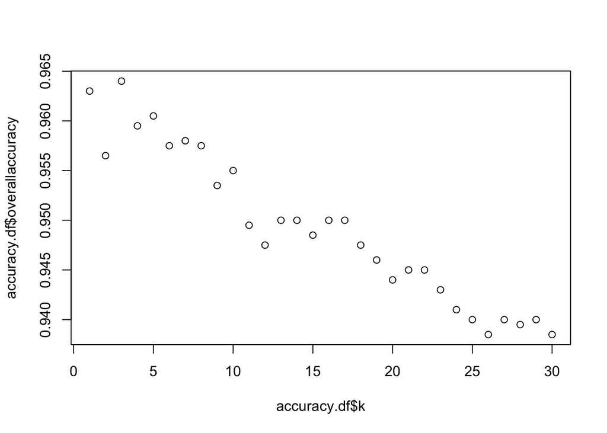

```r
plot(accuracy.df$k,accuracy.df$overallaccuracy)
```

```r
#best value of K is 3
```

Q3. Show the confusion matrix for the validation data that results from using the best k

```r
pred_k.3 <- class::knn(train = train.norm.df, test = valid.norm.df, cl = train.df$Personal.Loan, k = 3)
confusionMatrix(pred_k.3,as.factor(valid.df$Personal.Loan))
```

```
## Confusion Matrix and Statistics
##
##           Reference
## Prediction    0    1
##          0 1786   63
##          1    9  142
##
##                Accuracy : 0.964
##                  95% CI : (0.9549, 0.9717)
##     No Information Rate : 0.8975
##     P-Value [Acc > NIR] : < 2.2e-16
##
##                   Kappa : 0.7785
##
##  Mcnemar's Test P-Value : 4.208e-10
##
##             Sensitivity : 0.9950
##             Specificity : 0.6927
##          Pos Pred Value : 0.9659
##          Neg Pred Value : 0.9404
##              Prevalence : 0.8975
##          Detection Rate : 0.8930
##    Detection Prevalence : 0.9245
##       Balanced Accuracy : 0.8438
##
##        'Positive' Class : 0
##
```

Q4. Consider the following customer: Age = 40, Experience = 10, Income = 84, Family = 2, CCAvg = 2, Education_1 = 0, Education_2 = 1, Education_3 = 0, Mortgage = 0, Securities Account = 0, CD Account = 0, Online = 1 and Credit Card = 1. Classify the customer using the best k.

```r
#Creating a data frame of second customer
second_customer = data.frame(Age = 40, Experience = 10, Income = 84,Family = 2, CCAvg = 2, Education.1 = 0, Education.2 = 1, Education.3 = 0, Mortgage = 0, Securities.Account = 0, CD.Account = 0, Online = 1, CreditCard = 1)
# Normalizing second customer
second_customer <- predict(norm,second_customer)
#Predicting using knn
second_pred = class::knn(train = train.norm.df, test = second_customer, cl = train.df$Personal.Loan,k = 3)
second_pred
```

```
## [1] 0
## Levels: 0 1
```

```r
#Second customer is also classified as unlikely to accept a loan
```

Q5. Repartition the data, this time into training, validation, and test sets (50% : 30% : 20%). Apply the k-NN method with the k chosen above. Compare the confusion matrix of the test set with that of the training and validation sets. Comment on the differences and their reason.

```r
#Partition the data into training (50%), validation (30%) and testing set (20%)
set.seed(1)
train_index <- sample(row.names(universal.bank.df),0.5*dim(universal.bank.df)[1])
valid_index <- sample(setdiff(row.names(universal.bank.df),train_index),0.3*dim(universal.bank.df)[1])
test_index <- setdiff(row.names(universal.bank.df),union(train_index, valid_index))
train.df <- universal.bank.df[train_index,]
valid.df <- universal.bank.df[valid_index,]
test.df <- universal.bank.df[test_index,]
dim(train.df)
```

```
## [1] 2500   14
```

```r
dim(valid.df)
```

```
## [1] 1500   14
```

```r
dim(test.df)
```

```
## [1] 1000   14
```

```r
#Normalizing the data
norm <- preProcess(train.df[, -10], method=c("center", "scale"))
train.norm.df <- predict(norm, train.df[, -10])
valid.norm.df <- predict(norm, valid.df[, -10])
test.norm.df <- predict(norm,test.df[,-10])
#Predicting using knn
#confusion matrix of the training and test set
pred_knn1 <- class::knn(train = train.norm.df, test = test.norm.df, cl = train.df$Personal.Loan, k = 3)
confusionMatrix(pred_knn1, as.factor(test.df$Personal.Loan))
```

```
## Confusion Matrix and Statistics
##
##           Reference
## Prediction   0   1
##          0 884  35
##          1   4  77
##
##                Accuracy : 0.961
##                  95% CI : (0.9471, 0.9721)
##     No Information Rate : 0.888
##     P-Value [Acc > NIR] : < 2.2e-16
##
##                   Kappa : 0.777
##
##  Mcnemar's Test P-Value : 1.556e-06
##
##             Sensitivity : 0.9955
##             Specificity : 0.6875
##          Pos Pred Value : 0.9619
##          Neg Pred Value : 0.9506
##              Prevalence : 0.8880
##          Detection Rate : 0.8840
##    Detection Prevalence : 0.9190
##       Balanced Accuracy : 0.8415
##
##        'Positive' Class : 0
##
```

```r
#confusion matrix of the training and valid set
pred_knn2 <- class::knn(train = train.norm.df, test = valid.norm.df, cl = train.df$Personal.Loan, k = 3)
confusionMatrix(pred_knn2, as.factor(valid.df$Personal.Loan))
```

```
## Confusion Matrix and Statistics
##
##           Reference
## Prediction    0    1
##          0 1358   42
##          1    6   94
##
##                Accuracy : 0.968
##                  95% CI : (0.9578, 0.9763)
##     No Information Rate : 0.9093
##     P-Value [Acc > NIR] : < 2.2e-16
##
##                   Kappa : 0.7797
##
##  Mcnemar's Test P-Value : 4.376e-07
##
##             Sensitivity : 0.9956
##             Specificity : 0.6912
##          Pos Pred Value : 0.9700
##          Neg Pred Value : 0.9400
##              Prevalence : 0.9093
##          Detection Rate : 0.9053
##    Detection Prevalence : 0.9333
##       Balanced Accuracy : 0.8434
##
##        'Positive' Class : 0
##
```

```r
#confusion matrix of the training set
pred_knn3 <- class::knn(train = train.norm.df, test = train.norm.df, cl = train.df$Personal.Loan, k = 3)
confusionMatrix(pred_knn3, as.factor(train.df$Personal.Loan))
```

```
## Confusion Matrix and Statistics
##
##           Reference
## Prediction    0    1
##          0 2263   54
##          1    5  178
##
##                Accuracy : 0.9764
##                  95% CI : (0.9697, 0.982)
##     No Information Rate : 0.9072
##     P-Value [Acc > NIR] : < 2.2e-16
##
##                   Kappa : 0.8452
##
##  Mcnemar's Test P-Value : 4.129e-10
##
##             Sensitivity : 0.9978
##             Specificity : 0.7672
##          Pos Pred Value : 0.9767
##          Neg Pred Value : 0.9727
##              Prevalence : 0.9072
##          Detection Rate : 0.9052
##    Detection Prevalence : 0.9268
##       Balanced Accuracy : 0.8825
##
##        'Positive' Class : 0
##
```